# 🌊 Statistical Modelling of Ocean Waves

Based on Rychlik, Johannesson & Leadbetter (1997)

```python
import numpy as np
import matplotlib.pyplot as plt
from scipy import signal
from scipy.stats import norm, rayleigh, gaussian_kde
from scipy.interpolate import UnivariateSpline

np.random.seed(50)
```

```python
BLUE = "#1F4E79"
MIDBLUE = "#2E75B6"
ORANGE = "#E05C00"

plt.rcParams.update({
    "figure.facecolor": "#F9FBFE",
    "axes.edgecolor": BLUE,
    "axes.labelcolor": BLUE,
})
```

```python
# Sampling frequency [Hz]
# Fs = 2 means we generate 2 data points every second
Fs = 2.0

# Total simulation time [seconds]
T = 1122.0

# Create time array:
# starts at 0 sec, ends before T, with spacing = 1/Fs
# Example: 0, 0.5, 1.0, 1.5 ...
t = np.arange(0, T, 1/Fs)


# ------------------------------------------------------------------
# Frequency components used to build the irregular wave signal
# ------------------------------------------------------------------

# Create 200 frequency components between 0.04 Hz and 0.30 Hz
# Lower frequency = long waves
# Higher frequency = short waves
freqs_comp = np.linspace(0.04, 0.30, 200)

# Peak frequency [Hz]
# This is the frequency where most wave energy is concentrated
fp = 0.10


# ------------------------------------------------------------------
# JONSWAP-type spectral shaping
# ------------------------------------------------------------------

# sigma controls the width of the spectral peak
# Lower side of peak uses 0.07
# Higher side of peak uses 0.09
# This asymmetry is common in ocean wave spectra
sigma = np.where(freqs_comp <= fp, 0.07, 0.09)

# Peak enhancement term
# Makes the spectrum sharper around the peak frequency
r = np.exp(-((freqs_comp - fp)**2) / (2 * sigma**2 * fp**2))

# Base spectral shape
# Similar to Pierson-Moskowitz/JONSWAP formulation
# freq^-5 term controls high-frequency decay
# exponential term controls low-frequency behaviour
S_comp = (freqs_comp**(-5) * np.exp(-1.25*(freqs_comp/fp)**(-4)))

# Normalize spectrum so maximum value becomes 1
# Easier for numerical scaling and visualization
S_comp /= S_comp.max()


# ------------------------------------------------------------------
# Convert spectral energy into wave amplitudes
# ------------------------------------------------------------------

# Amplitude corresponding to each frequency component
# sqrt(2*S/N) converts spectral density into sinusoidal amplitudes
amplitudes = np.sqrt(2 * S_comp / len(freqs_comp))

# Random phase assigned to each frequency component
# This randomness creates an irregular sea state
phases = np.random.uniform(0, 2*np.pi, len(freqs_comp))


# ------------------------------------------------------------------
# Construct irregular wave signal
# ------------------------------------------------------------------

# Initialize empty signal
X = np.zeros(len(t))

# Add sinusoidal components one-by-one
# Each component has:
#   a   -> amplitude
#   f   -> frequency
#   phi -> random phase
for a, f, phi in zip(amplitudes, freqs_comp, phases):

    # Sum all sinusoidal wave components
    X += a * np.sin(2*np.pi*f*t + phi)


# ------------------------------------------------------------------
# Introduce mild non-linearity
# ------------------------------------------------------------------

# Add quadratic contribution
# This creates slightly sharper crests and flatter troughs,
# which is more realistic for ocean waves
X = X + 0.18 * X**2 / np.std(X)

# Remove mean value so signal oscillates around zero
X -= np.mean(X)


# ------------------------------------------------------------------
# Final statistical parameter
# ------------------------------------------------------------------

# Standard deviation of generated signal
# Often related to wave energy or significant wave height scaling
sigma_X = np.std(X)
```

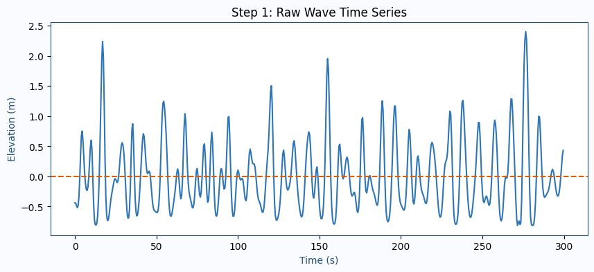

```python
plt.figure(figsize=(10,4))
plt.plot(t[t<300], X[t<300], color=MIDBLUE)
plt.axhline(0, linestyle="--", color=ORANGE)

plt.title("Step 1: Raw Wave Time Series")
plt.xlabel("Time (s)")
plt.ylabel("Elevation (m)")
plt.show()
```

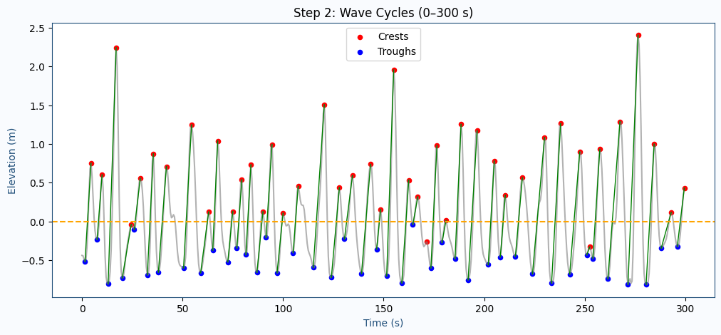

```python
from scipy.signal import argrelextrema

# Find local maxima (wave crests)
# order=4 means point must be greater than 4 neighbouring points
idx_max = argrelextrema(X, np.greater, order=4)[0]

# Find local minima (wave troughs)
idx_min = argrelextrema(X, np.less, order=4)[0]

# Sort indices in increasing time order
idx_max = np.sort(idx_max)
idx_min = np.sort(idx_min)


# -------------------------------------------------------
# Pair each trough with the next crest
# -------------------------------------------------------

pairs = []
i, j = 0, 0

while i < len(idx_min) and j < len(idx_max):

    # Valid wave cycle:
    # trough occurs first, then crest
    if idx_min[i] < idx_max[j]:

        # Store pair of indices
        pairs.append((idx_min[i], idx_max[j]))

        i += 1
        j += 1

    else:
        # Skip crest if it occurs before trough
        j += 1

pairs = np.array(pairs)


# -------------------------------------------------------
# Keep only first 300 seconds for plotting
# -------------------------------------------------------

mask_max = t[idx_max] < 300
mask_min = t[idx_min] < 300

# Use trough time for filtering wave pairs
mask_pairs = t[pairs[:,0]] < 300

idx_max_f = idx_max[mask_max]
idx_min_f = idx_min[mask_min]
pairs_f   = pairs[mask_pairs]


# -------------------------------------------------------
# Plot signal and detected wave cycles
# -------------------------------------------------------

plt.figure(figsize=(12,5))

# Show only first 300 s of signal
show = t < 300
plt.plot(t[show], X[show], color="grey", alpha=0.6)

# Draw line from trough to crest
for imin, imax in pairs_f:

    plt.plot([t[imin], t[imax]],
             [X[imin], X[imax]],
             color="green", lw=1)

# Plot crest points
plt.scatter(t[idx_max_f], X[idx_max_f],
            color="red", s=20, label="Crests")

# Plot trough points
plt.scatter(t[idx_min_f], X[idx_min_f],
            color="blue", s=20, label="Troughs")

# Mean water level
plt.axhline(0, linestyle="--", color="orange")

plt.title("Step 2: Wave Cycles (0–300 s)")
plt.xlabel("Time (s)")
plt.ylabel("Elevation (m)")
plt.legend()

plt.show()
```

### Meaning of Crossing Intensity

Crossing intensity $\mu(u)$ represents:

$$ \mu(u) $$

the average rate at which the wave signal crosses a particular level $u$.

In this implementation, a crossing is counted when:

- trough value $m < u$
- crest value $M > u$

which means the wave cycle passes through the level $u$.

### Physical Interpretation

If:

$$ \mu(1.0) = 0.02 $$

then the sea surface crosses the level of $1.0 \, m$ approximately:

- $0.02$ times per second
- or once every $50$ seconds on average.

### Behaviour of the Curve

- Near the mean water level ($u \approx 0$):
  - crossings are frequent
  - many waves pass through this level
- At higher levels:
  - crossings become rare
  - only large waves exceed those elevations

Therefore, the crossing intensity curve decreases as $u$ increases.

### Importance in Offshore Engineering

Crossing intensity is commonly used in:

- extreme wave analysis
- deck wetness assessment
- slamming analysis
- fatigue cycle estimation
- reliability studies

It helps estimate:

> "How often does the response exceed a certain level?"

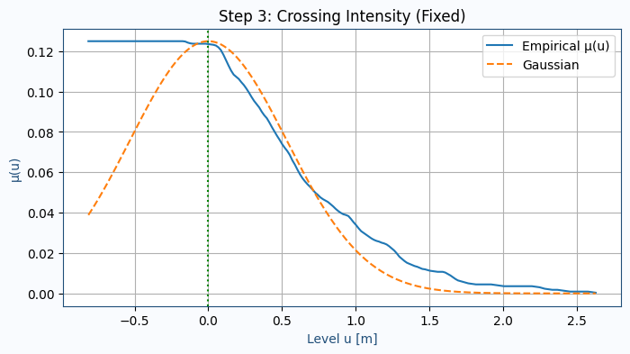

```python
# Trough values from each wave pair
m_vals = X[pairs[:,0]]

# Crest values from each wave pair
M_vals = X[pairs[:,1]]


# Create level range for evaluation
# u represents different elevation levels
u_grid = np.linspace(X.min(), X.max(), 200)


# -------------------------------------------------------
# Crossing intensity function
# -------------------------------------------------------

def crossing(u):

    # Count waves crossing level u
    # Condition:
    # trough below u AND crest above u
    return np.sum((m_vals < u) & (M_vals > u)) / T


# Compute crossing intensity for all levels
mu_hat = np.array([crossing(u) for u in u_grid])


# -------------------------------------------------------
# Smooth the curve
# -------------------------------------------------------

# Moving average smoothing
# Helps remove small numerical fluctuations
mu_hat = np.convolve(mu_hat, np.ones(5)/5, mode='same')


# -------------------------------------------------------
# Enforce physical behaviour
# -------------------------------------------------------

# Crossing intensity should decrease
# as level becomes larger
mu_hat = np.maximum.accumulate(mu_hat[::-1])[::-1]


# -------------------------------------------------------
# Gaussian reference model
# -------------------------------------------------------

# Standard deviation of signal
sigma_X = np.std(X)

# Peak crossing intensity
mu_0 = mu_hat.max()

# Ideal Gaussian crossing curve
mu_gauss = mu_0 * np.exp(-u_grid**2 / (2 * sigma_X**2))


# -------------------------------------------------------
# Plot results
# -------------------------------------------------------

plt.figure(figsize=(8,4))

# Empirical crossing intensity
plt.plot(u_grid, mu_hat, label="Empirical μ(u)")

# Gaussian reference
plt.plot(u_grid, mu_gauss, '--', label="Gaussian")

# Mean water level
plt.axvline(0, linestyle=":", color="green")

plt.xlabel("Level u [m]")
plt.ylabel("μ(u)")
plt.title("Step 3: Crossing Intensity (Fixed)")

plt.legend()
plt.grid(True)

plt.show()
```

### Transformation Function

The transformation function $g(u)$ converts the original non-Gaussian wave elevation into an equivalent Gaussian variable.

$$ g(u) $$

The idea is:

- real ocean waves are often nonlinear and non-Gaussian
- Gaussian processes are mathematically easier to analyze
- therefore, a transformation is used to map the measured signal into Gaussian space

In this method, the transformation is derived from the crossing intensity function $\mu(u)$.

If the transformed curve follows a straight Gaussian reference line, the process behaves close to Gaussian.

Deviations from the Gaussian line indicate nonlinear wave behaviour such as:

- sharper crests
- flatter troughs
- asymmetry in wave shape

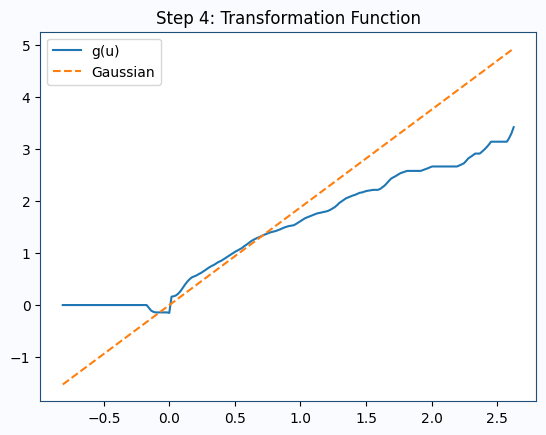

```python
# Maximum crossing intensity
# Used for normalization
mu_max = mu_hat.max()

# Normalize crossing intensity between 0 and 1
# clip() avoids log(0) errors
mu_safe = np.clip(mu_hat/mu_max, 1e-6, 1)


# -------------------------------------------------------
# Compute transformed variable ψ
# -------------------------------------------------------

# Based on Gaussian crossing relationship
# Higher levels correspond to larger ψ values
psi = -2 * np.log(mu_safe)


# -------------------------------------------------------
# Transformation function g(u)
# -------------------------------------------------------

# Convert ψ into transformed Gaussian space
# sign(u) preserves positive/negative side
g_hat = np.sign(u_grid) * np.sqrt(np.abs(psi))


# -------------------------------------------------------
# Plot transformation
# -------------------------------------------------------

# Empirical transformation function
plt.plot(u_grid, g_hat, label="g(u)")

# Ideal Gaussian transformation reference
# Standardized variable: (x-mean)/std
plt.plot(u_grid,
         (u_grid-np.mean(X))/sigma_X,
         "--",
         label="Gaussian")

plt.legend()

plt.title("Step 4: Transformation Function")

plt.show()
```

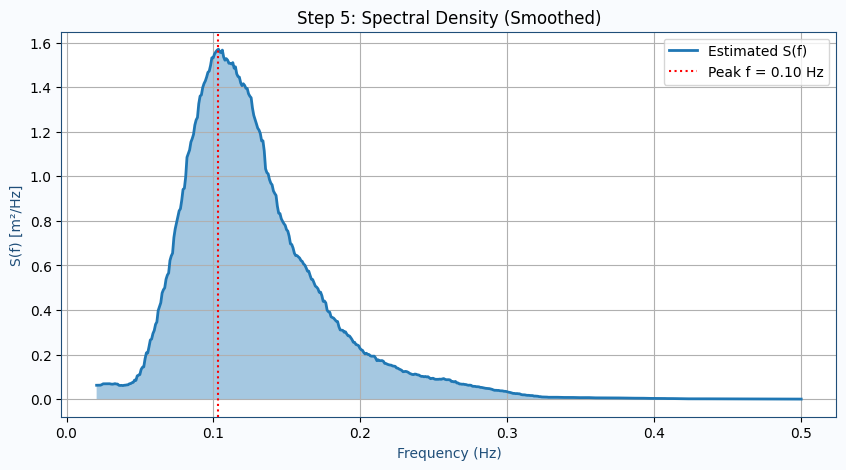

```python
# -------------------------------------------------------
# Step 5 — Spectral Density Estimation
# -------------------------------------------------------

# Frequency values corresponding to FFT components
# rfftfreq is used because signal is real-valued
f_fft = np.fft.rfftfreq(len(X), d=1/Fs)

# Fast Fourier Transform of signal
# Converts time-domain signal into frequency-domain
X_fft = np.fft.rfft(X)


# -------------------------------------------------------
# Power Spectral Density (PSD)
# -------------------------------------------------------

# PSD represents how wave energy is distributed
# across different frequencies
S = (np.abs(X_fft)**2) / (len(X) * Fs)


# -------------------------------------------------------
# Smooth spectrum
# -------------------------------------------------------

# Moving-average smoothing function
# Helps remove noisy spikes from FFT result
def smooth(arr, window=40):

    kernel = np.ones(window) / window

    return np.convolve(arr, kernel, mode='same')


# Smoothed spectral density
S_smooth = smooth(S, 60)


# -------------------------------------------------------
# Plot only useful frequency range
# -------------------------------------------------------

# Ignore extremely low/high frequencies
mask = (f_fft > 0.02) & (f_fft < 0.5)

plt.figure(figsize=(10,5))


# Filled spectrum plot
plt.fill_between(f_fft[mask],
                 S_smooth[mask],
                 alpha=0.4)

# Main spectrum curve
plt.plot(f_fft[mask],
         S_smooth[mask],
         linewidth=2,
         label="Estimated S(f)")


# -------------------------------------------------------
# Peak frequency
# -------------------------------------------------------

# Frequency where spectral energy is maximum
fp = f_fft[np.argmax(S_smooth)]

# Plot peak frequency location
plt.axvline(fp,
            linestyle=":",
            color="red",
            label=f"Peak f = {fp:.2f} Hz")


# -------------------------------------------------------
# Plot formatting
# -------------------------------------------------------

plt.title("Step 5: Spectral Density (Smoothed)")

plt.xlabel("Frequency (Hz)")
plt.ylabel("S(f) [m²/Hz]")

plt.legend()
plt.grid(True)

plt.show()
```

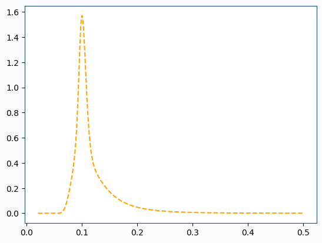

```python
# -------------------------------------------------------
# JONSWAP Spectrum Function
# -------------------------------------------------------

# JONSWAP is a commonly used ocean wave spectrum
# for developing sea states

def jonswap(f, fp=0.10, gamma=3.3):

    # Avoid division by zero at f = 0
    f = np.clip(f, 1e-6, None)

    # Spectral width parameter
    # Different values below and above peak frequency
    sigma = np.where(f <= fp, 0.07, 0.09)

    # Peak enhancement term
    # Controls sharpness around peak frequency
    r = np.exp(-((f - fp)**2) / (2 * sigma**2 * fp**2))

    # JONSWAP spectral equation
    S = (f**(-5) *
         np.exp(-1.25*(f/fp)**(-4)) *
         gamma**r)

    # Normalize spectrum
    S /= np.max(S)

    # Scale to match estimated spectrum magnitude
    return S * np.max(S_smooth)


# Compute theoretical JONSWAP spectrum
S_j = jonswap(f_fft)


# -------------------------------------------------------
# Plot JONSWAP reference
# -------------------------------------------------------

# Compare theoretical spectrum
# against estimated spectrum
plt.plot(f_fft[mask],
         S_j[mask],
         '--',
         label="JONSWAP",
         color="orange")
```

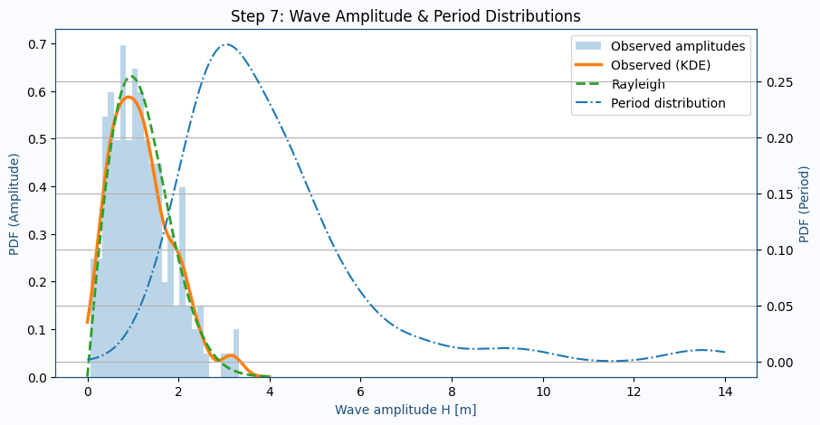

```python
# -------------------------------------------------------
# Step 7 — Wave Amplitude & Period Distributions
# -------------------------------------------------------

# Wave amplitude:
# crest elevation - trough elevation
H_vals = X[pairs[:,1]] - X[pairs[:,0]]

# Wave period:
# time difference between trough and crest
T_vals = (pairs[:,1] - pairs[:,0]) / Fs


from scipy.stats import gaussian_kde, rayleigh


# -------------------------------------------------------
# Amplitude distribution
# -------------------------------------------------------

# KDE = smooth probability density estimate
# for observed wave amplitudes
kde_H = gaussian_kde(H_vals, bw_method=0.3)

# Grid for plotting amplitude PDF
H_grid = np.linspace(0, max(H_vals)*1.2, 200)

# Estimated amplitude probability density
pdf_H = kde_H(H_grid)


# -------------------------------------------------------
# Rayleigh reference distribution
# -------------------------------------------------------

# Rayleigh distribution is commonly used
# for Gaussian sea wave amplitudes
scale = np.sqrt(np.mean(H_vals**2)/2)

# Theoretical Rayleigh PDF
pdf_rayleigh = rayleigh.pdf(H_grid, scale=scale)


# -------------------------------------------------------
# Period distribution
# -------------------------------------------------------

# Ignore unrealistically small periods
kde_T = gaussian_kde(T_vals[T_vals > 0.5],
                     bw_method=0.3)

# Grid for plotting period PDF
T_grid = np.linspace(0, max(T_vals), 200)

# Estimated period probability density
pdf_T = kde_T(T_grid)


# -------------------------------------------------------
# Plot distributions
# -------------------------------------------------------

fig, ax1 = plt.subplots(figsize=(10,5))


# Histogram of observed amplitudes
ax1.hist(H_vals,
         bins=25,
         density=True,
         alpha=0.3,
         label="Observed amplitudes")


# KDE amplitude distribution
ax1.plot(H_grid,
         pdf_H,
         linewidth=2.5,
         label="Observed (KDE)")


# Rayleigh reference curve
ax1.plot(H_grid,
         pdf_rayleigh,
         '--',
         linewidth=2,
         label="Rayleigh")


ax1.set_xlabel("Wave amplitude H [m]")
ax1.set_ylabel("PDF (Amplitude)")


# -------------------------------------------------------
# Secondary axis for wave periods
# -------------------------------------------------------

ax2 = ax1.twinx()

# Wave period distribution
ax2.plot(T_grid,
         pdf_T,
         linestyle='-.',
         label="Period distribution")

ax2.set_ylabel("PDF (Period)")


# -------------------------------------------------------
# Combine legends from both axes
# -------------------------------------------------------

lines1, labels1 = ax1.get_legend_handles_labels()
lines2, labels2 = ax2.get_legend_handles_labels()

ax1.legend(lines1 + lines2,
           labels1 + labels2)


plt.title("Step 7: Wave Amplitude & Period Distributions")

plt.grid(True)

plt.show()
```

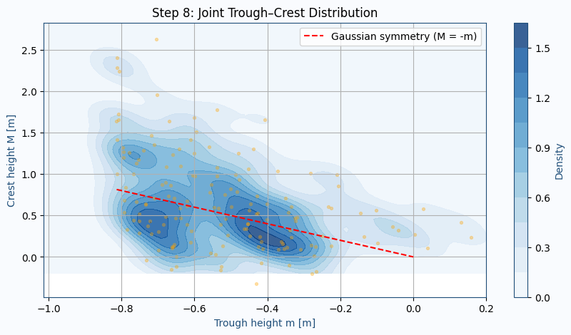

```python
# --- Step 8: Joint Distribution ---

m_vals = X[pairs[:,0]]
M_vals = X[pairs[:,1]]

from scipy.stats import gaussian_kde

data = np.vstack([m_vals, M_vals])
kde = gaussian_kde(data, bw_method=0.25)

# Grid
m_grid = np.linspace(min(m_vals)-0.2, 0.2, 80)
M_grid = np.linspace(-0.2, max(M_vals)+0.2, 80)

mg, Mg = np.meshgrid(m_grid, M_grid)
Z = kde(np.vstack([mg.ravel(), Mg.ravel()])).reshape(mg.shape)

# --- Plot ---
plt.figure(figsize=(10,5))

# Contour
plt.contourf(mg, Mg, Z, levels=12, cmap="Blues", alpha=0.8)
plt.colorbar(label="Density")

# Scatter points
plt.scatter(m_vals, M_vals, s=8, alpha=0.3, color="orange")

# Gaussian symmetry line
m_line = np.linspace(min(m_vals), 0, 50)
plt.plot(m_line, -m_line, '--', color='red', label="Gaussian symmetry (M = -m)")

plt.xlabel("Trough height m [m]")
plt.ylabel("Crest height M [m]")

plt.title("Step 8: Joint Trough–Crest Distribution")
plt.legend()

plt.grid(True)
plt.show()
```

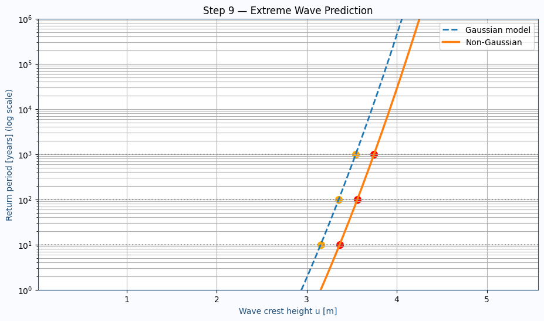

```
----- DESIGN WAVES -----

σ = 0.532 m
ν₀ = 0.139 Hz

Gaussian:
10-year   : 3.15 m
100-year  : 3.36 m
1000-year : 3.54 m

Non-Gaussian:
10-year   : 3.37 m
100-year  : 3.56 m
1000-year : 3.75 m
```

```python
# -------------------------------------------------------
# Step 9 — Extreme Wave Prediction (CORRECTED)
# -------------------------------------------------------

# Standard deviation of wave elevation
sigma_X = np.std(X)

# -------------------------------------------------------
# Crest height range for prediction
# -------------------------------------------------------

# Extended range for extreme extrapolation
u_ext = np.linspace(
    0.5 * sigma_X,
    10 * sigma_X,
    5000
)

# -------------------------------------------------------
# Spectral moments
# -------------------------------------------------------

m0 = np.trapz(S_smooth, f_fft)

m2 = np.trapz(
    (2*np.pi*f_fft)**2 * S_smooth,
    f_fft
)

# -------------------------------------------------------
# Mean zero-upcrossing frequency
# -------------------------------------------------------

nu0 = (1/(2*np.pi)) * np.sqrt(m2/m0)

# -------------------------------------------------------
# Gaussian exceedance intensity
# -------------------------------------------------------
#
# Rayleigh exceedance model for crest amplitudes
#
# P(C > u) = exp(-u² / (2σ²))
#
# Crossing intensity:
#
# μ(u) = ν0 * P(C > u)
#
# -------------------------------------------------------

mu_G = nu0 * np.exp(
    -(u_ext**2) / (2 * sigma_X**2)
)

# -------------------------------------------------------
# Non-Gaussian correction
# -------------------------------------------------------

nG_factor = (
    1
    + 0.6 *
    np.clip(
        (u_ext/sigma_X - 1),
        0,
        None
    )**1.7
)

mu_NG = mu_G * nG_factor

# -------------------------------------------------------
# Return period
# -------------------------------------------------------

sec_per_year = 365.25 * 24 * 3600

# events/sec → years/event
Tr_G = 1 / (mu_G * sec_per_year)

Tr_NG = 1 / (mu_NG * sec_per_year)

# -------------------------------------------------------
# VERY IMPORTANT FIX
# -------------------------------------------------------
#
# np.interp REQUIRES ascending x-array
#
# Return periods naturally become:
#
# small crest → small Tr
# large crest → huge Tr
#
# but numerical noise may break monotonicity
#
# so explicitly sort them
#
# -------------------------------------------------------

idxG = np.argsort(Tr_G)
idxNG = np.argsort(Tr_NG)

Tr_G_sorted = Tr_G[idxG]
u_G_sorted = u_ext[idxG]

Tr_NG_sorted = Tr_NG[idxNG]
u_NG_sorted = u_ext[idxNG]

# -------------------------------------------------------
# Design waves
# -------------------------------------------------------

u10_G = np.interp(
    10,
    Tr_G_sorted,
    u_G_sorted
)

u100_G = np.interp(
    100,
    Tr_G_sorted,
    u_G_sorted
)

u1000_G = np.interp(
    1000,
    Tr_G_sorted,
    u_G_sorted
)

u10_NG = np.interp(
    10,
    Tr_NG_sorted,
    u_NG_sorted
)

u100_NG = np.interp(
    100,
    Tr_NG_sorted,
    u_NG_sorted
)

u1000_NG = np.interp(
    1000,
    Tr_NG_sorted,
    u_NG_sorted
)

# -------------------------------------------------------
# Plot
# -------------------------------------------------------

plt.figure(figsize=(11,6))

plt.semilogy(
    u_ext,
    Tr_G,
    '--',
    linewidth=2,
    label="Gaussian model"
)

plt.semilogy(
    u_ext,
    Tr_NG,
    linewidth=2.5,
    label="Non-Gaussian"
)

# Reference lines
for rp in [10, 100, 1000]:
    plt.axhline(
        rp,
        linestyle=":",
        color="grey",
        alpha=0.7
    )

# Scatter points
plt.scatter([u10_G], [10], color="orange", s=70)
plt.scatter([u100_G], [100], color="orange", s=70)
plt.scatter([u1000_G], [1000], color="orange", s=70)

plt.scatter([u10_NG], [10], color="red", s=70)
plt.scatter([u100_NG], [100], color="red", s=70)
plt.scatter([u1000_NG], [1000], color="red", s=70)

# Labels
plt.xlabel("Wave crest height u [m]")

plt.ylabel("Return period [years] (log scale)")

plt.title("Step 9 — Extreme Wave Prediction")

plt.grid(True, which="both")

plt.legend()

plt.ylim(1, 1e6)

plt.show()

# -------------------------------------------------------
# Results
# -------------------------------------------------------

print("\n----- DESIGN WAVES -----\n")

print(f"σ = {sigma_X:.3f} m")
print(f"ν₀ = {nu0:.3f} Hz\n")

print("Gaussian:")
print(f"10-year   : {u10_G:.2f} m")
print(f"100-year  : {u100_G:.2f} m")
print(f"1000-year : {u1000_G:.2f} m\n")

print("Non-Gaussian:")
print(f"10-year   : {u10_NG:.2f} m")
print(f"100-year  : {u100_NG:.2f} m")
print(f"1000-year : {u1000_NG:.2f} m")
```